# Assigning ASVs to Snail Microbiome Trimmed Data

Daphne Garcia

2025-03-12

#Setting the seed

```r
# Any number can be chosen
set.seed(238428)

n_threads = 40
```

#Timing

```r
# What time did we start running this script?
start_time <- Sys.time()
start_time
```

```
## [1] "2025-03-14 09:53:07 EDT"
```

#Load Libraries

```r
pacman::p_load(tidyverse, devtools, dada2,
               patchwork, DT, install = FALSE)
```

#Load in Filtered fastqs

```r
# Place filtered reads into filtered_fastqs_path
filtered_fastqs_path <- "data/data_filtered"

# Intuition Check
filtered_fastqs_path
```

```
## [1] "data/data_filtered"
```

```r
# create 2 vectors: filtered_forward_reads & filtered_reverse_reads
filtered_forward_reads <-
  list.files(filtered_fastqs_path, pattern = "_R1_filtered.fastq.gz",
             full.names = TRUE)

# reverse reads
filtered_reverse_reads <-
    list.files(filtered_fastqs_path, pattern = "_R2_filtered.fastq.gz",
             full.names = TRUE)

# Intuition Checks
length(filtered_forward_reads)
```

```
## [1] 60
```

```r
length(filtered_reverse_reads)
```

```
## [1] 60
```

# Assign Sample Names

```r
sample_names <- sapply(strsplit(basename(filtered_forward_reads), "_"), `[`,1)

# Intuition Check
head(sample_names)
```

```
## [1] "SRR19509095" "SRR19509096" "SRR19509097" "SRR19509098" "SRR19509099"
## [6] "SRR19509100"
```

#Learn the errors: MiSeq Runs: 40 Phred Scores

```r
# Forward Reads
error_forward_reads <-
  learnErrors(filtered_forward_reads, multithread = n_threads)
```

```
## 110248452 total bases in 485676 reads from 5 samples will be used for learning the error rates.
```

```r
forward_error_plot <-
  plotErrors(error_forward_reads, nominalQ = TRUE) +
  labs(title = "Forward Reads: Error Model")



# Reverse Reads
error_reverse_reads <-
  learnErrors(filtered_reverse_reads, multithread = n_threads)
```

```
## 107334396 total bases in 485676 reads from 5 samples will be used for learning the error rates.
```

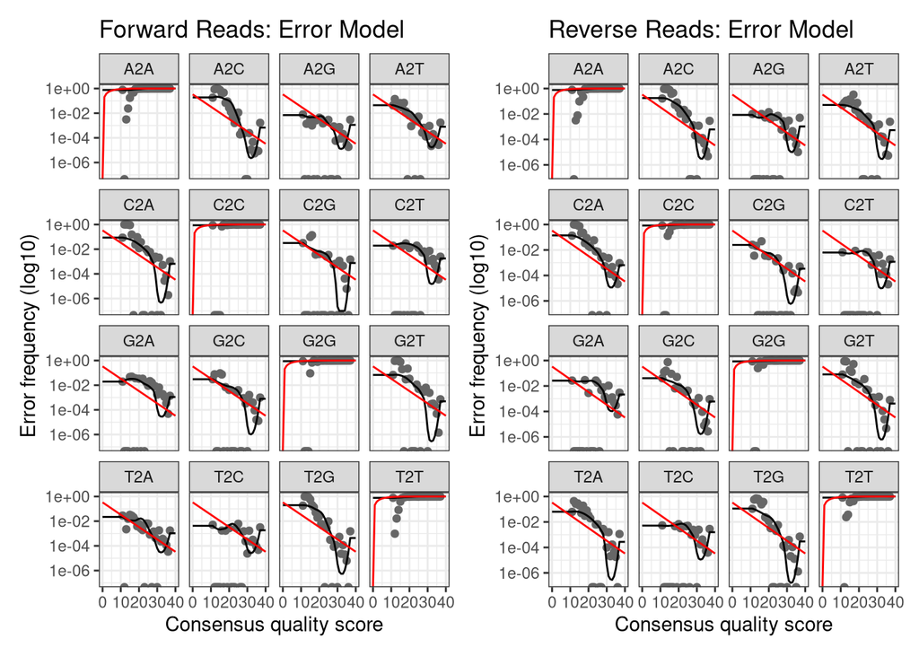

```r
reverse_error_plot <-
  plotErrors(error_reverse_reads, nominalQ = TRUE) +
  labs(title = "Reverse Reads: Error Model")


# Look at the plots together
forward_error_plot + reverse_error_plot
```

# Infer ASVs on forward sequences

```r
# Infer ASVs on the forward sequences
dada_forward <-
  dada(filtered_forward_reads,
       err = error_forward_reads,
       multithread = n_threads)
```

```
## Sample 1 - 96422 reads in 21057 unique sequences.
## Sample 2 - 87907 reads in 18391 unique sequences.
## Sample 3 - 97485 reads in 19610 unique sequences.
## Sample 4 - 97172 reads in 22185 unique sequences.
## Sample 5 - 106690 reads in 34046 unique sequences.
## Sample 6 - 100285 reads in 29363 unique sequences.
## Sample 7 - 108721 reads in 29335 unique sequences.
## Sample 8 - 100233 reads in 30812 unique sequences.
## Sample 9 - 106099 reads in 27121 unique sequences.
## Sample 10 - 98168 reads in 24861 unique sequences.
## Sample 11 - 103483 reads in 31979 unique sequences.
## Sample 12 - 98933 reads in 24988 unique sequences.
## Sample 13 - 100470 reads in 26410 unique sequences.
## Sample 14 - 104704 reads in 33632 unique sequences.
## Sample 15 - 100877 reads in 17544 unique sequences.
## Sample 16 - 105910 reads in 30235 unique sequences.
## Sample 17 - 99386 reads in 32441 unique sequences.
## Sample 18 - 95752 reads in 29432 unique sequences.
## Sample 19 - 105917 reads in 31100 unique sequences.
## Sample 20 - 99359 reads in 35216 unique sequences.
## Sample 21 - 95214 reads in 27993 unique sequences.
## Sample 22 - 108331 reads in 34848 unique sequences.
## Sample 23 - 105353 reads in 29705 unique sequences.
## Sample 24 - 93830 reads in 22334 unique sequences.
## Sample 25 - 100932 reads in 29912 unique sequences.
## Sample 26 - 87332 reads in 22409 unique sequences.
## Sample 27 - 101251 reads in 30011 unique sequences.
## Sample 28 - 98322 reads in 28590 unique sequences.
## Sample 29 - 106271 reads in 28450 unique sequences.
## Sample 30 - 96461 reads in 27583 unique sequences.
## Sample 31 - 101220 reads in 33026 unique sequences.
## Sample 32 - 96151 reads in 23153 unique sequences.
## Sample 33 - 101570 reads in 26942 unique sequences.
## Sample 34 - 106464 reads in 25375 unique sequences.
## Sample 35 - 107345 reads in 24742 unique sequences.
## Sample 36 - 98445 reads in 27244 unique sequences.
## Sample 37 - 102402 reads in 22218 unique sequences.
## Sample 38 - 102504 reads in 31151 unique sequences.
## Sample 39 - 98456 reads in 20519 unique sequences.
## Sample 40 - 91424 reads in 27410 unique sequences.
## Sample 41 - 105298 reads in 31358 unique sequences.
## Sample 42 - 77469 reads in 10699 unique sequences.
## Sample 43 - 96197 reads in 15641 unique sequences.
## Sample 44 - 94744 reads in 21845 unique sequences.
## Sample 45 - 105590 reads in 20585 unique sequences.
## Sample 46 - 94024 reads in 21891 unique sequences.
## Sample 47 - 97814 reads in 23836 unique sequences.
## Sample 48 - 86950 reads in 25355 unique sequences.
## Sample 49 - 88919 reads in 18430 unique sequences.
## Sample 50 - 101332 reads in 34177 unique sequences.
## Sample 51 - 96484 reads in 32592 unique sequences.
## Sample 52 - 93082 reads in 28755 unique sequences.
## Sample 53 - 97805 reads in 19554 unique sequences.
## Sample 54 - 91263 reads in 25038 unique sequences.
## Sample 55 - 90461 reads in 23843 unique sequences.
## Sample 56 - 97291 reads in 23836 unique sequences.
## Sample 57 - 101708 reads in 22766 unique sequences.
## Sample 58 - 99433 reads in 25877 unique sequences.
## Sample 59 - 102383 reads in 24241 unique sequences.
## Sample 60 - 79550 reads in 19655 unique sequences.
```

## Intuition checks for forward ASVs infererence

```r
typeof(dada_forward) # It's a list
```

```
## [1] "list"
```

```r
length(dada_forward) # How big is it? One per sample!
```

```
## [1] 60
```

```r
dada_forward$`SRR19509095_R1_filtered.fastq.gz` #D note: name of first of list
```

```
## dada-class: object describing DADA2 denoising results
## 663 sequence variants were inferred from 21057 input unique sequences.
## Key parameters: OMEGA_A = 1e-40, OMEGA_C = 1e-40, BAND_SIZE = 16
```

# Infer ASVs on reverse sequences

```r
dada_reverse <-
  dada(filtered_reverse_reads,
       err = error_reverse_reads ,
       multithread = n_threads)
```

```
## Sample 1 - 96422 reads in 15499 unique sequences.
## Sample 2 - 87907 reads in 13654 unique sequences.
## Sample 3 - 97485 reads in 14843 unique sequences.
## Sample 4 - 97172 reads in 17006 unique sequences.
## Sample 5 - 106690 reads in 26093 unique sequences.
## Sample 6 - 100285 reads in 23238 unique sequences.
## Sample 7 - 108721 reads in 23907 unique sequences.
## Sample 8 - 100233 reads in 25305 unique sequences.
## Sample 9 - 106099 reads in 21552 unique sequences.
## Sample 10 - 98168 reads in 19964 unique sequences.
## Sample 11 - 103483 reads in 25355 unique sequences.
## Sample 12 - 98933 reads in 18371 unique sequences.
## Sample 13 - 100470 reads in 19341 unique sequences.
## Sample 14 - 104704 reads in 25829 unique sequences.
## Sample 15 - 100877 reads in 14204 unique sequences.
## Sample 16 - 105910 reads in 22587 unique sequences.
## Sample 17 - 99386 reads in 26250 unique sequences.
## Sample 18 - 95752 reads in 20682 unique sequences.
## Sample 19 - 105917 reads in 22933 unique sequences.
## Sample 20 - 99359 reads in 27708 unique sequences.
## Sample 21 - 95214 reads in 20654 unique sequences.
## Sample 22 - 108331 reads in 26640 unique sequences.
## Sample 23 - 105353 reads in 22997 unique sequences.
## Sample 24 - 93830 reads in 17327 unique sequences.
## Sample 25 - 100932 reads in 22977 unique sequences.
## Sample 26 - 87332 reads in 17738 unique sequences.
## Sample 27 - 101251 reads in 23351 unique sequences.
## Sample 28 - 98322 reads in 21900 unique sequences.
## Sample 29 - 106271 reads in 23094 unique sequences.
## Sample 30 - 96461 reads in 22325 unique sequences.
## Sample 31 - 101220 reads in 25686 unique sequences.
## Sample 32 - 96151 reads in 18377 unique sequences.
## Sample 33 - 101570 reads in 21072 unique sequences.
## Sample 34 - 106464 reads in 18309 unique sequences.
## Sample 35 - 107345 reads in 17930 unique sequences.
## Sample 36 - 98445 reads in 20731 unique sequences.
## Sample 37 - 102402 reads in 16198 unique sequences.
## Sample 38 - 102504 reads in 23268 unique sequences.
## Sample 39 - 98456 reads in 15716 unique sequences.
## Sample 40 - 91424 reads in 22969 unique sequences.
## Sample 41 - 105298 reads in 23141 unique sequences.
## Sample 42 - 77469 reads in 8086 unique sequences.
## Sample 43 - 96197 reads in 11456 unique sequences.
## Sample 44 - 94744 reads in 17244 unique sequences.
## Sample 45 - 105590 reads in 15672 unique sequences.
## Sample 46 - 94024 reads in 18105 unique sequences.
## Sample 47 - 97814 reads in 17757 unique sequences.
## Sample 48 - 86950 reads in 20276 unique sequences.
## Sample 49 - 88919 reads in 14163 unique sequences.
## Sample 50 - 101332 reads in 25502 unique sequences.
## Sample 51 - 96484 reads in 25269 unique sequences.
## Sample 52 - 93082 reads in 20922 unique sequences.
## Sample 53 - 97805 reads in 13185 unique sequences.
## Sample 54 - 91263 reads in 17569 unique sequences.
## Sample 55 - 90461 reads in 16680 unique sequences.
## Sample 56 - 97291 reads in 16956 unique sequences.
## Sample 57 - 101708 reads in 15812 unique sequences.
## Sample 58 - 99433 reads in 17875 unique sequences.
## Sample 59 - 102383 reads in 19390 unique sequences.
## Sample 60 - 79550 reads in 15395 unique sequences.
```

## Intuition checks for reverse ASVs infererence

```r
typeof(dada_reverse) # It's a list
```

```
## [1] "list"
```

```r
length(dada_reverse) # How big is it? One per sample!
```

```
## [1] 60
```

```r
dada_reverse$`SRR19509095_R2_filtered.fastq.gz` #D note: name of first of list
```

```
## dada-class: object describing DADA2 denoising results
## 782 sequence variants were inferred from 15499 input unique sequences.
## Key parameters: OMEGA_A = 1e-40, OMEGA_C = 1e-40, BAND_SIZE = 16
```

# Merge Forward and Reverse ASVs

```r
merged_ASVs <-
  mergePairs(dada_forward, filtered_forward_reads,
             dada_reverse, filtered_reverse_reads,
             verbose = TRUE)
```

```
## 87854 paired-reads (in 2972 unique pairings) successfully merged out of 92981 (in 6110 pairings) input.
```

```
## 81615 paired-reads (in 2367 unique pairings) successfully merged out of 85140 (in 4504 pairings) input.
```

```
## 91155 paired-reads (in 3677 unique pairings) successfully merged out of 95056 (in 6002 pairings) input.
```

```
## 88314 paired-reads (in 3573 unique pairings) successfully merged out of 93529 (in 6720 pairings) input.
```

```
## 89705 paired-reads (in 8949 unique pairings) successfully merged out of 99007 (in 15078 pairings) input.
```

```
## 87311 paired-reads (in 5897 unique pairings) successfully merged out of 93852 (in 10131 pairings) input.
```

```
## 95255 paired-reads (in 4585 unique pairings) successfully merged out of 101955 (in 8550 pairings) input.
```

```
## 84865 paired-reads (in 7961 unique pairings) successfully merged out of 92737 (in 13136 pairings) input.
```

```
## 95678 paired-reads (in 4999 unique pairings) successfully merged out of 101288 (in 8509 pairings) input.
```

```
## 88636 paired-reads (in 6761 unique pairings) successfully merged out of 94608 (in 10627 pairings) input.
```

```
## 88861 paired-reads (in 9387 unique pairings) successfully merged out of 96867 (in 14567 pairings) input.
```

```
## 91101 paired-reads (in 6048 unique pairings) successfully merged out of 95529 (in 8952 pairings) input.
```

```
## 92031 paired-reads (in 5892 unique pairings) successfully merged out of 97146 (in 9161 pairings) input.
```

```
## 90576 paired-reads (in 10047 unique pairings) successfully merged out of 98453 (in 15406 pairings) input.
```

```
## 94313 paired-reads (in 3866 unique pairings) successfully merged out of 98509 (in 6389 pairings) input.
```

```
## 94859 paired-reads (in 7648 unique pairings) successfully merged out of 101865 (in 12147 pairings) input.
```

```
## 85462 paired-reads (in 10081 unique pairings) successfully merged out of 92952 (in 15157 pairings) input.
```

```
## 87008 paired-reads (in 6775 unique pairings) successfully merged out of 92318 (in 9962 pairings) input.
```

```
## 95999 paired-reads (in 7552 unique pairings) successfully merged out of 101885 (in 11387 pairings) input.
```

```
## 84668 paired-reads (in 11082 unique pairings) successfully merged out of 92835 (in 16516 pairings) input.
```

```
## 84739 paired-reads (in 8389 unique pairings) successfully merged out of 90580 (in 12163 pairings) input.
```

```
## 92066 paired-reads (in 10440 unique pairings) successfully merged out of 100112 (in 15902 pairings) input.
```

```
## 93187 paired-reads (in 10370 unique pairings) successfully merged out of 99862 (in 14969 pairings) input.
```

```
## 84843 paired-reads (in 4898 unique pairings) successfully merged out of 89556 (in 8016 pairings) input.
```

```
## 88483 paired-reads (in 8720 unique pairings) successfully merged out of 95413 (in 13480 pairings) input.
```

```
## 77805 paired-reads (in 3302 unique pairings) successfully merged out of 83207 (in 6518 pairings) input.
```

```
## 90408 paired-reads (in 4913 unique pairings) successfully merged out of 96435 (in 8733 pairings) input.
```

```
## 87649 paired-reads (in 4846 unique pairings) successfully merged out of 93593 (in 8538 pairings) input.
```

```
## 95237 paired-reads (in 5010 unique pairings) successfully merged out of 101266 (in 8889 pairings) input.
```

```
## 85170 paired-reads (in 5058 unique pairings) successfully merged out of 91527 (in 9038 pairings) input.
```

```
## 88042 paired-reads (in 6014 unique pairings) successfully merged out of 95422 (in 10696 pairings) input.
```

```
## 87081 paired-reads (in 5634 unique pairings) successfully merged out of 92569 (in 9021 pairings) input.
```

```
## 91379 paired-reads (in 3470 unique pairings) successfully merged out of 96556 (in 6672 pairings) input.
```

```
## 98581 paired-reads (in 3874 unique pairings) successfully merged out of 103617 (in 6796 pairings) input.
```

```
## 99967 paired-reads (in 3715 unique pairings) successfully merged out of 104513 (in 6433 pairings) input.
```

```
## 87221 paired-reads (in 4630 unique pairings) successfully merged out of 93691 (in 8578 pairings) input.
```

```
## 93477 paired-reads (in 3444 unique pairings) successfully merged out of 98488 (in 6503 pairings) input.
```

```
## 86082 paired-reads (in 6100 unique pairings) successfully merged out of 93577 (in 10868 pairings) input.
```

```
## 91029 paired-reads (in 7280 unique pairings) successfully merged out of 95225 (in 9998 pairings) input.
```

```
## 75097 paired-reads (in 5492 unique pairings) successfully merged out of 82525 (in 10364 pairings) input.
```

```
## 89758 paired-reads (in 6210 unique pairings) successfully merged out of 97303 (in 11134 pairings) input.
```

```
## 73346 paired-reads (in 934 unique pairings) successfully merged out of 76166 (in 1459 pairings) input.
```

```
## 88955 paired-reads (in 1758 unique pairings) successfully merged out of 93959 (in 3211 pairings) input.
```

```
## 83591 paired-reads (in 2525 unique pairings) successfully merged out of 88801 (in 5868 pairings) input.
```

```
## 96081 paired-reads (in 2712 unique pairings) successfully merged out of 102346 (in 4943 pairings) input.
```

```
## 83543 paired-reads (in 3089 unique pairings) successfully merged out of 89870 (in 6900 pairings) input.
```

```
## 88680 paired-reads (in 3995 unique pairings) successfully merged out of 94066 (in 7284 pairings) input.
```

```
## 74164 paired-reads (in 3923 unique pairings) successfully merged out of 80564 (in 7695 pairings) input.
```

```
## 79908 paired-reads (in 4594 unique pairings) successfully merged out of 85435 (in 7587 pairings) input.
```

```
## 81235 paired-reads (in 5061 unique pairings) successfully merged out of 91345 (in 10543 pairings) input.
```

```
## 73112 paired-reads (in 4872 unique pairings) successfully merged out of 86194 (in 10354 pairings) input.
```

```
## 78754 paired-reads (in 4247 unique pairings) successfully merged out of 85193 (in 8207 pairings) input.
```

```
## 89969 paired-reads (in 3328 unique pairings) successfully merged out of 94807 (in 5598 pairings) input.
```

```
## 79254 paired-reads (in 6825 unique pairings) successfully merged out of 86576 (in 11335 pairings) input.
```

```
## 80269 paired-reads (in 4268 unique pairings) successfully merged out of 86272 (in 7667 pairings) input.
```

```
## 87078 paired-reads (in 3753 unique pairings) successfully merged out of 92896 (in 7088 pairings) input.
```

```
## 92799 paired-reads (in 3121 unique pairings) successfully merged out of 97923 (in 6135 pairings) input.
```

```
## 87881 paired-reads (in 3289 unique pairings) successfully merged out of 95022 (in 6775 pairings) input.
```

```
## 91891 paired-reads (in 4059 unique pairings) successfully merged out of 97575 (in 7514 pairings) input.
```

```
## 71884 paired-reads (in 4416 unique pairings) successfully merged out of 76877 (in 7399 pairings) input.
```

## Intuition checks for merging

```r
typeof(merged_ASVs) # It's a list
```

```
## [1] "list"
```

```r
length(merged_ASVs) # How big is it? One per sample!
```

```
## [1] 60
```

```r
head(names(merged_ASVs)) # Here, we can access our current sample names (all R1)
```

```
## [1] "SRR19509095_R1_filtered.fastq.gz" "SRR19509096_R1_filtered.fastq.gz"
## [3] "SRR19509097_R1_filtered.fastq.gz" "SRR19509098_R1_filtered.fastq.gz"
## [5] "SRR19509099_R1_filtered.fastq.gz" "SRR19509100_R1_filtered.fastq.gz"
```

```r
# Inspect further for each sample
#head(merged_ASVs, n = 2) # A dataframe for each sample
# We have a dataframe in each part of our list! What are in the columns?
glimpse(merged_ASVs$`SRR19509149_R1_filtered.fastq.gz`)
```

```
## Rows: 4,268
## Columns: 9
## $ sequence  <chr> "TGGGGAATATTGCACAATGGGGGAAACCCTGATGCAGCCATGCCGCGTGTGTGAAGAAG…
## $ abundance <int> 8554, 4674, 4615, 2622, 2039, 1645, 1579, 1447, 1435, 1116, …
## $ forward   <int> 1, 2, 4, 3, 5, 6, 9, 7, 8, 12, 10, 11, 19, 14, 15, 16, 17, 1…
## $ reverse   <int> 1, 4, 3, 2, 2, 6, 5, 1, 7, 9, 8, 2, 14, 12, 16, 18, 10, 13, …
## $ nmatch    <int> 19, 19, 24, 19, 19, 44, 19, 19, 19, 24, 19, 19, 23, 19, 19, …
## $ nmismatch <int> 0, 0, 0, 0, 0, 0, 0, 0, 0, 0, 0, 0, 0, 0, 0, 0, 0, 0, 0, 0, …
## $ nindel    <int> 0, 0, 0, 0, 0, 0, 0, 0, 0, 0, 0, 0, 0, 0, 0, 0, 0, 0, 0, 0, …
## $ prefer    <dbl> 2, 2, 2, 2, 2, 2, 2, 2, 2, 2, 2, 2, 2, 2, 2, 1, 2, 2, 2, 1, …
## $ accept    <lgl> TRUE, TRUE, TRUE, TRUE, TRUE, TRUE, TRUE, TRUE, TRUE, TRUE, …
```

#Create Raw ASV Count Table

```r
# Raw ASV
raw_ASV_table <- makeSequenceTable(merged_ASVs)

# Intuition Check: Type and dimensions of the data
dim(raw_ASV_table)
```

```
## [1]     60 159739
```

```r
typeof(raw_ASV_table)
```

```
## [1] "integer"
```

```r
class(raw_ASV_table)
```

```
## [1] "matrix" "array"
```

```r
# write out raw_asv_table
write.table(raw_ASV_table, file = "data/data_filtered/raw_ASV_counts.tsv",
            sep = "\t", quote = FALSE, col.names = NA)
```

INTERPRETATION #1

1. Sequencing strategy: Illumina NovaSeq 6000 paired end 2x250. Specifically, 341F and 806R so 1 - (806-341)/(2x250) = 7% overlap.
2. 806-341 = 465, with primers
3. The paper used primers: 314 Forward (5′-CCTAYGGGRBGCASCAG-3′), 806 Reverse (5′GGACTACNNGGGTATCTAAT-3′), which are 17 and 20 respectively. 465 - 17 - 20 = 428

Therefore, I expect the ASV length without primers to be 428 bp long

4. The length of trimmed ASVs: Since there were adapters before the primers of different lengths, I had to I used trimLeft =c(23,26) instead of 17 and 20. I also used truncLen = c(250,247), Therefore, 465 - 23 - 26 - 3 = 413
5. from the multiQC report: “All samples have sequences of a single length (250bp)”. Therefore, if the legnth of trimmed reads is 413, overlap is 34.8%

#ASV Length Stats

```r
# Calculate summary stats
# Longest ASV?
maxLength_ASV <- max(nchar(getSequences(raw_ASV_table)))

# Shortest ASV?
minLength_ASV <- min(nchar(getSequences(raw_ASV_table)))

# Mean ASV length?
meanLength_ASV <- mean(nchar(getSequences(raw_ASV_table)))

# Median ASV length?
medianLength_ASV <- median(nchar(getSequences(raw_ASV_table)))

# Create a table to Inspect the distribution of sequence lengths of all ASVs in dataset
table(nchar(getSequences(raw_ASV_table)))
```

```
##
##    227    232    234    235    238    241    242    244    247    248    249
##      2      1      1      1      1      1      1      1      1      1      2
##    250    251    252    254    255    256    258    260    262    264    265
##      1      2      1      2      1      1      1      1      2      2      4
##    270    275    276    277    279    281    286    288    290    291    297
##      1      1      1      1      1      1      2      1      1      1      2
##    298    299    301    302    303    305    306    307    308    309    310
##      2      2      2      1      2      2      1      1      1      3     10
##    312    315    316    317    318    319    320    321    322    324    325
##      3      1      2     10      5      2      5      2      2      1      4
##    326    327    328    330    331    333    334    335    336    337    338
##      3      6      2      2      5      2      4      5      2     10      6
##    339    340    341    342    343    344    345    347    348    349    350
##      2      2      6      3      4      5      6      4      1      5      2
```

[output cut: 16 more lines]

# ASV length plot RAW

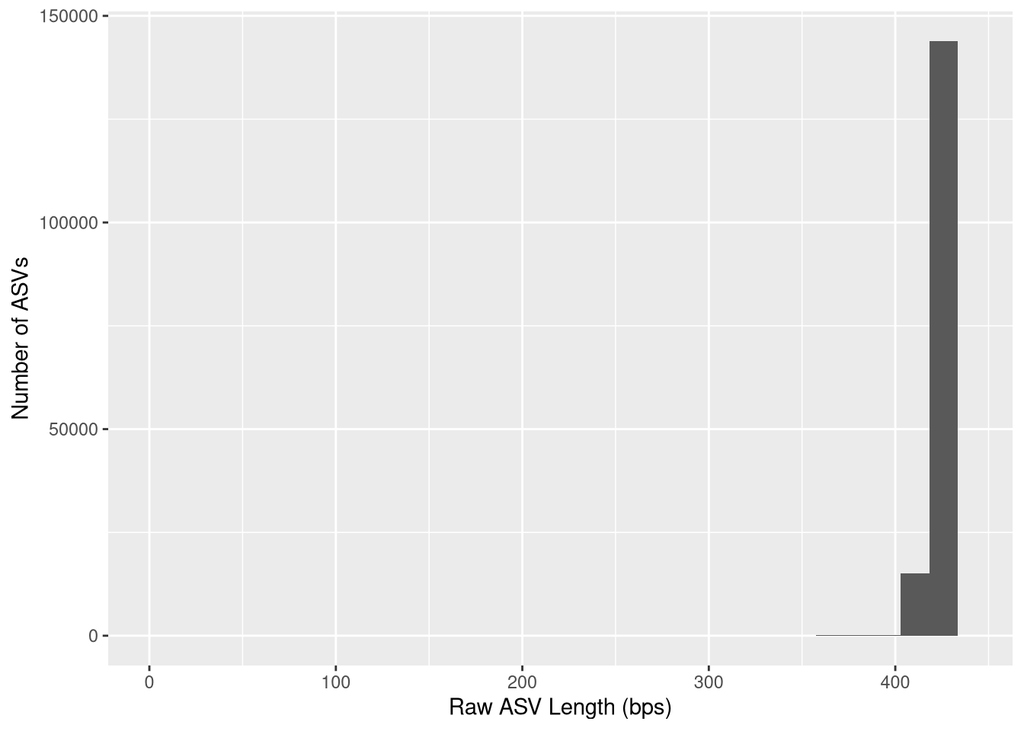

```r
# Inspect the distribution of sequence lengths of all ASVs in data set
# AFTER TRIM
plot_ASVLength_raw <-
  data.frame(Seq_Length = nchar(getSequences(raw_ASV_table))) %>%
  ggplot(aes(x = Seq_Length )) +
  geom_histogram() +
  # include the x-axis scales
  scale_x_continuous(limits = c(0, maxLength_ASV + 5)) +
  labs(y = "Number of ASVs", x = "Raw ASV Length (bps)")

# Show the plot
plot_ASVLength_raw
```

** Also, I originally tried trimming to exact length of 429, and only got a 67% retention rate

# Trim ASV lengths

```r
# Subset only ASVs that are between 425 and 430 (chatgpt)
raw_ASV_table_trimmed <-
  raw_ASV_table[, nchar(colnames(raw_ASV_table)) >= 424 & nchar(colnames(raw_ASV_table)) <= 430]

# Inspect the distribution of sequence lengths of all ASVs in dataset
table(nchar(getSequences(raw_ASV_table_trimmed)))
```

```
##
##    424    425    426    427    428    429    430
##  12784   1221    355    552   4652 112272   9496
```

```r
# What proportion of total ASV sequences are left in the data?
percRetained_Trimmed <- sum(raw_ASV_table_trimmed)/sum(raw_ASV_table)
percRetained_Trimmed # Show it
```

```
## [1] 0.8821435
```

When I’m trimming everything that isn’t 429, I get 67.8% When I trim a range between 424 and 430 (424 has 12K and 430 has 9k ASVs), percent retained = 88.2%

# Inspect distribution of seq lengths after trim

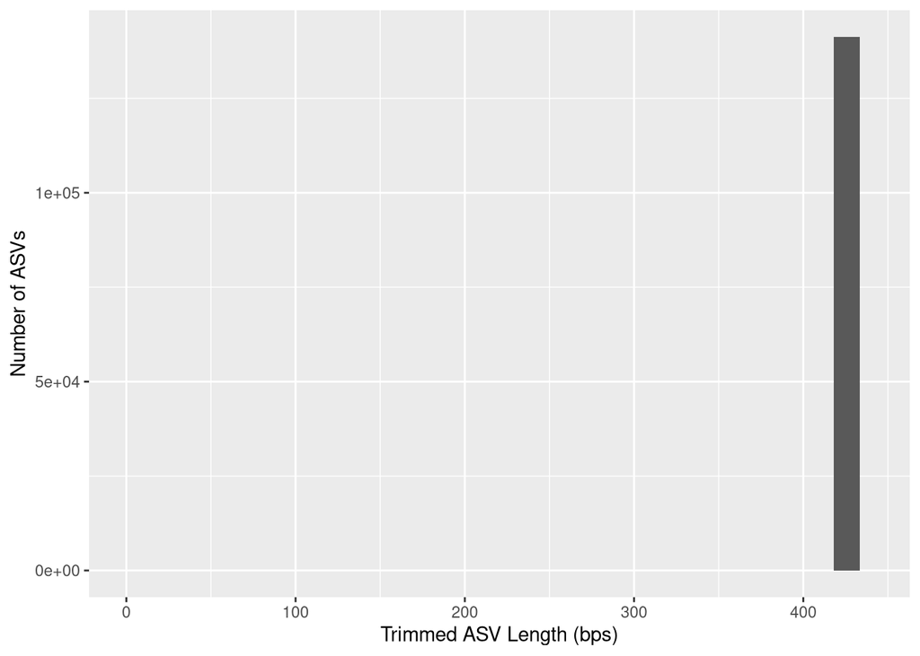

```r
# Inspect the distribution of sequence lengths of all ASVs in dataset
# AFTER TRIM
plot_ASVLength_trimmed <-
  data.frame(Seq_Length = nchar(getSequences(raw_ASV_table_trimmed))) %>%
  ggplot(aes(x = Seq_Length )) +
  geom_histogram() +
  # include the x-axis scales
  scale_x_continuous(limits = c(0, maxLength_ASV + 5)) +
  labs(y = "Number of ASVs", x = "Trimmed ASV Length (bps)")

# Show the plot
plot_ASVLength_trimmed
```

#Removing Chimeras

```r
# Remove the chimeras in the raw ASV table
noChimeras_ASV_table <-
  removeBimeraDenovo(raw_ASV_table_trimmed,
                     method="consensus",
                     multithread = n_threads,
                     verbose=TRUE)
```

```
## Identified 123475 bimeras out of 141332 input sequences.
```

```r
# Check the dimensions
dim(noChimeras_ASV_table)
```

```
## [1]    60 17857
```

(bimera is two parent chimera)

```r
# What proportion is left of the sequences?
# Chimera removal compared to trimming  0.75
percRetained_chimerasTrimmed <- sum(noChimeras_ASV_table)/sum(raw_ASV_table_trimmed)
# Chimera removal compared to raw   0.67
percRetained_chimerasRaw <-sum(noChimeras_ASV_table)/sum(raw_ASV_table)
```

Chimera removal compared to trimming 0.7598 Chimera removal compared to raw 0.6702

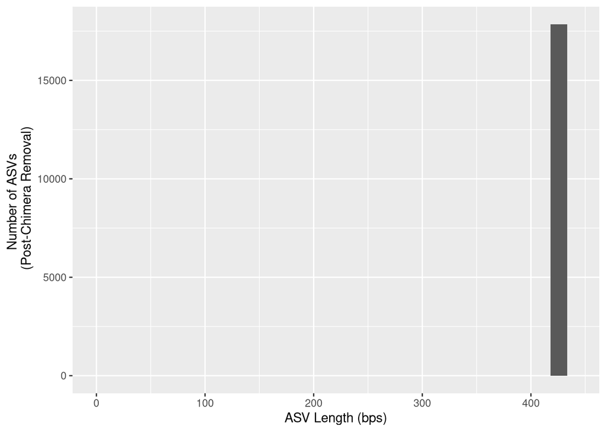

```r
# Plot it
plot_ASVLength_NoChimeras <-
  data.frame(Seq_Length_NoChim = nchar(getSequences(noChimeras_ASV_table))) %>%
  ggplot(aes(x = Seq_Length_NoChim )) +
  geom_histogram()+
  # include the x-axis scales
  scale_x_continuous(limits = c(0, maxLength_ASV + 5)) +
  labs(y = "Number of ASVs \n (Post-Chimera Removal)",
       x = "ASV Length (bps)")

# Show the plot
plot_ASVLength_NoChimeras
```

# Plot ASV Lengths

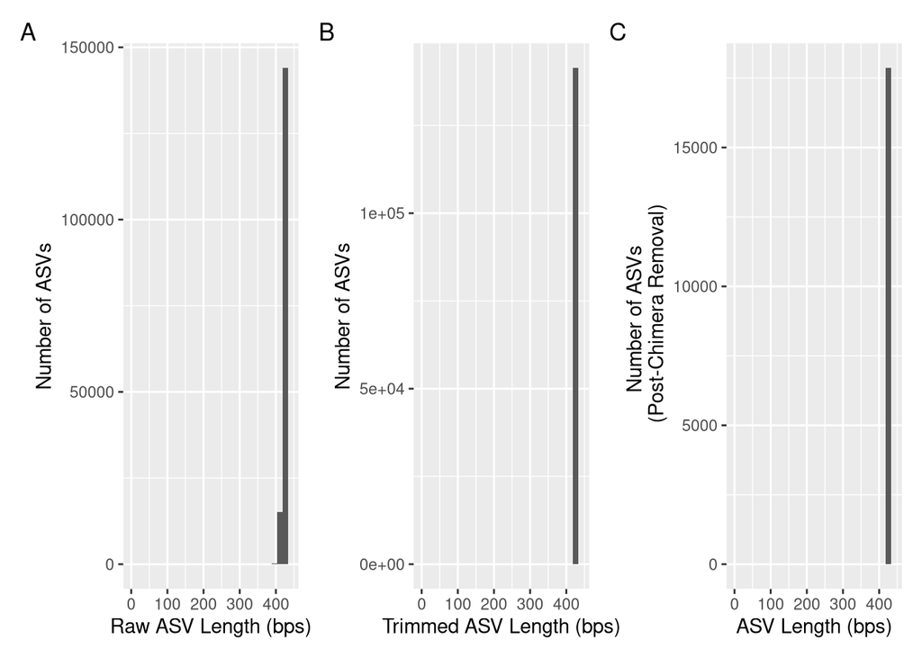

```r
plot_ASVLength_raw + plot_ASVLength_trimmed + plot_ASVLength_NoChimeras +
    plot_annotation(tag_levels = 'A')
```

#Track read counts

```r
# A little function to identify number seqs
getN <- function(x) sum(getUniques(x))

# Make the table to track the seqs
track <- cbind(sapply(dada_forward, getN),
               sapply(dada_reverse, getN),
               sapply(merged_ASVs, getN),
               rowSums(noChimeras_ASV_table))

head(track)
```

```
##                                    [,1]   [,2]  [,3]  [,4]
## SRR19509095_R1_filtered.fastq.gz  94686  94497 87854 67016
## SRR19509096_R1_filtered.fastq.gz  86700  86185 81615 51886
## SRR19509097_R1_filtered.fastq.gz  96278  96091 91155 63907
## SRR19509098_R1_filtered.fastq.gz  95458  95003 88314 58152
## SRR19509099_R1_filtered.fastq.gz 102411 102405 89705 53191
## SRR19509100_R1_filtered.fastq.gz  96536  96742 87311 62810
```

```r
# Update column names to be more informative (most are missing at the moment!)
colnames(track) <- c("denoisedF", "denoisedR", "merged", "nochim")
rownames(track) <- row.names(noChimeras_ASV_table)

# Generate a dataframe to track the reads through our DADA2 pipeline
track_counts_df <-
  track %>%
  # make it a dataframe
  as.data.frame() %>%
  rownames_to_column(var = "sample_names")

# Now let's add a column for the number of ASVs
# First, intuition check that the samples match
stopifnot(track_counts_df$sample_names == row.names(noChimeras_ASV_table))

# Now, let's add a new column with the number of ASVs
track_counts_df <-
  track_counts_df %>%
  mutate(num_ASVs = rowSums(noChimeras_ASV_table > 1))

# Visualize it in table format
DT::datatable(track_counts_df)
```

|  | sample_names | denoisedF | denoisedR | merged | nochim | num_ASVs |
| --- | --- | --- | --- | --- | --- | --- |
| 1 | SRR19509095_R1_filtered.fastq.gz | 94686 | 94497 | 87854 | 67016 | 419 |
| 2 | SRR19509096_R1_filtered.fastq.gz | 86700 | 86185 | 81615 | 51886 | 348 |
| 3 | SRR19509097_R1_filtered.fastq.gz | 96278 | 96091 | 91155 | 63907 | 372 |
| 4 | SRR19509098_R1_filtered.fastq.gz | 95458 | 95003 | 88314 | 58152 | 471 |
| 5 | SRR19509099_R1_filtered.fastq.gz | 102411 | 102405 | 89705 | 53191 | 661 |
| 6 | SRR19509100_R1_filtered.fastq.gz | 96536 | 96742 | 87311 | 62810 | 618 |
| 7 | SRR19509101_R1_filtered.fastq.gz | 105011 | 104681 | 95255 | 74893 | 629 |
| 8 | SRR19509102_R1_filtered.fastq.gz | 96288 | 95804 | 84865 | 52689 | 638 |
| 9 | SRR19509103_R1_filtered.fastq.gz | 103482 | 103343 | 95678 | 71370 | 455 |
| 10 | SRR19509104_R1_filtered.fastq.gz | 96462 | 96095 | 88636 | 61814 | 381 |

[output cut: 50 more lines]

# Plotting track counts

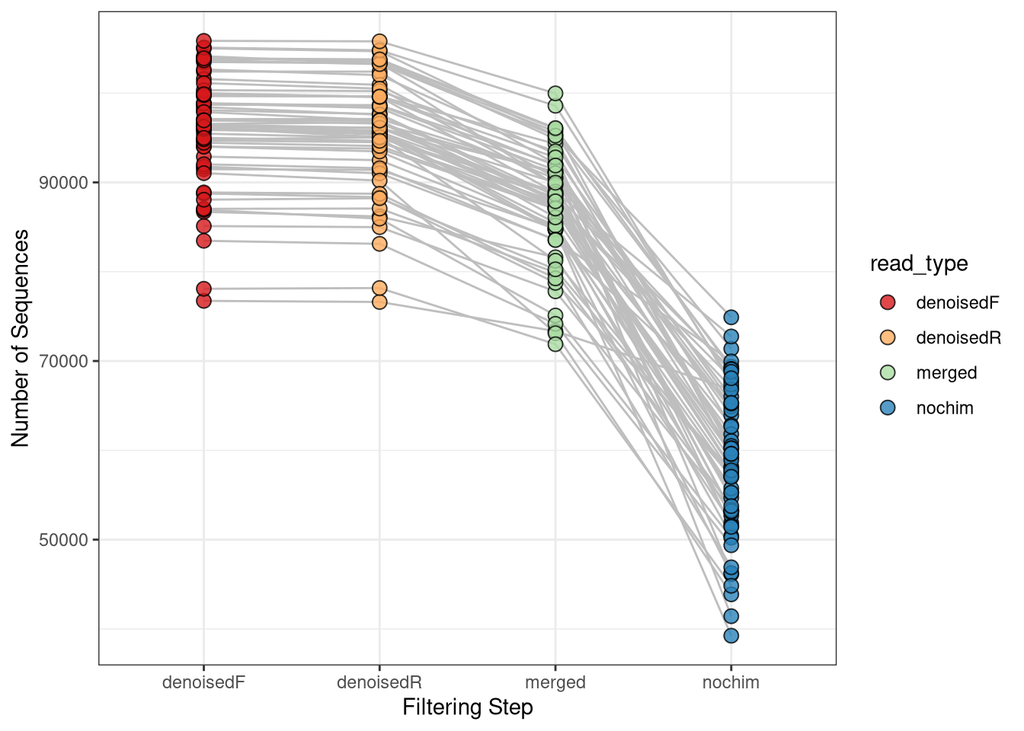

```r
# Plot it!
track_counts_df %>%
  pivot_longer(denoisedF:nochim, names_to = "read_type", values_to = "num_reads") %>%
  mutate(read_type = fct_relevel(read_type, "denoisedF", "denoisedR", "merged", "nochim")) %>%
  ggplot(aes(x = read_type, y = num_reads, fill = read_type)) +
  geom_line(aes(group = sample_names), color = "grey") +
  geom_point(shape = 21, size = 3, alpha = 0.8) +
  scale_fill_brewer(palette = "Spectral") +
  labs(x = "Filtering Step", y = "Number of Sequences") +
  theme_bw()
```

# Plotting number of maintained seq

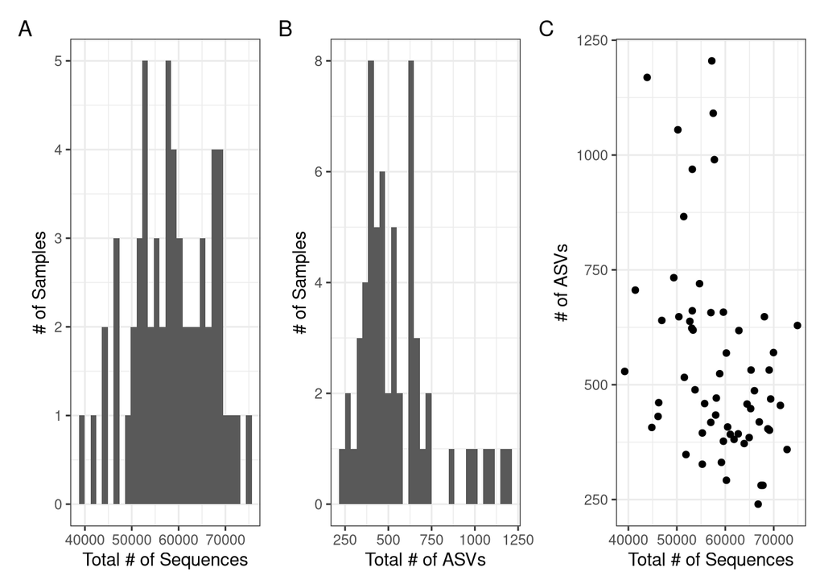

```r
plot_ReadDepth <-
  track_counts_df %>%
  ggplot(aes(x = nochim)) +
  geom_histogram() +
  labs(x = "Total # of Sequences", y = "# of Samples") +
  theme_bw()

# What is the ASV richness per sample?
plot_ASVRichness <-
  track_counts_df %>%
  ggplot(aes(x = num_ASVs)) +
  geom_histogram() +
  labs(x = "Total # of ASVs", y = "# of Samples") +
  theme_bw()

# Now, let's look at the relationship of ASVs and Sequencing depth
plot_ReadDepth_ASVRichness <-
  track_counts_df %>%
  ggplot(aes(x = nochim, y = num_ASVs)) +
  geom_point() +
  labs(x = "Total # of Sequences", y = "# of ASVs") +
  theme_bw()

# Show the plots together
plot_ReadDepth + plot_ASVRichness + plot_ReadDepth_ASVRichness +
    plot_annotation(tag_levels = 'A')
```

INTERPRETATION #5

Panel A: ASV Depth after DADA2 Histogram of sequencing depth per sample (Total # of Sequences)

Panel B: ASV Richness after DADA2: Histogram of ASV richness (Total # of ASVs per sample)

Panel C: Read Depth vs ASV Richness: Scatter plot showing the relationship between sequencing depth and ASV richness.

I would expect a positive correlation between higher read depth and more ASVs, however that doesn’t seem to be the case in my scatterplot. There is no correlation between number of sequences and number of ASVs. Generally, most points are below 750 ASV’s, regardless of number of sequences, and there’s 7 outliers that have over 750 ASVs. There’s also quite a few samples below 500 ASV’s, which I wasn’t able to see in panel B.

Overall Interpretation & Considerations:

Sequencing depth variation: Most samples are spread among a range of common sequencing depths, but there are a few sequences that are undersequenced.

ASV richness does not distinctly read depth trends: When viewing the scatterplot, there seems to be no correlation between number sequencing depth (num sequences) and richness (num ASVs), Rarefaction or normalization may definitely be needed, to hopefully standardize the read depth, as there is a range of depths. Since the plots do not suggest that richness is correlated or affected by read depth, rarefying might not have as large of an effect. What may be happening is that there may just be incredibly variable variation in snail microbiomes, but further analysis will be needed to assert what is going on.

#Assign Taxonomy

```r
# Assign up to genus level
taxa_train <-
  assignTaxonomy(noChimeras_ASV_table,
                 refFasta = "/workdir/in_class_data/taxonomy/silva_nr99_v138.2_toGenus_trainset.fa.gz",
                 multithread = 35)

# Add the genus/species information
taxa_addSpecies <-
  addSpecies(taxa_train,
              refFasta = "/workdir/in_class_data/taxonomy/silva_v138.2_assignSpecies.fa.gz")

# Inspect the taxonomy
glimpse(taxa_addSpecies) # Note that the rownames are the ASV sequences!
```

```
##  chr [1:17857, 1:7] "Bacteria" "Bacteria" "Bacteria" "Bacteria" "Bacteria" ...
##  - attr(*, "dimnames")=List of 2
##   ..$ : chr [1:17857] "TAGGGAATCTTCGGCAATGGACGAAAGTCTGACCGAGCAACGCCGCGTGAGTGAAGAAGGTTTTCGGATCGTAAAACTCTGTTGGTAGAGAAGAACGTTGGTGAGAGTGGA"| __truncated__ "TGAGGAATATTGGTCAATGGGTGCAAGCCTGAACCAGCCATCCCGCGTGAAGGACGACTGCCCTATGGGTTGTAAACTTCTTTTGTATAGGGATAAACCTCTCCTCGTGAG"| __truncated__ "TGGGGAATATTGCACA…
##   ..$ : chr [1:7] "Kingdom" "Phylum" "Class" "Order" ...
```

```r
# Let's removing the ASV sequence rownames for display only
taxa_print <- taxa_addSpecies
rownames(taxa_print) <- NULL
head(taxa_print)
```

```
##      Kingdom    Phylum           Class                 Order
## [1,] "Bacteria" "Bacillota"      "Bacilli"             "Lactobacillales"
## [2,] "Bacteria" "Bacteroidota"   "Bacteroidia"         "Flavobacteriales"
## [3,] "Bacteria" "Pseudomonadota" "Gammaproteobacteria" "Enterobacterales"
## [4,] "Bacteria" "Pseudomonadota" "Gammaproteobacteria" "Burkholderiales"
## [5,] "Bacteria" "Pseudomonadota" "Gammaproteobacteria" "Burkholderiales"
## [6,] "Bacteria" "Pseudomonadota" "Gammaproteobacteria" "Enterobacterales"
##      Family               Genus               Species
## [1,] "Streptococcaceae"   "Lactococcus"       NA
## [2,] "Weeksellaceae"      "Cloacibacterium"   NA
## [3,] "Aeromonadaceae"     "Tolumonas"         NA
## [4,] "Comamonadaceae"     "Hydrogenophaga"    NA
## [5,] "Chromobacteriaceae" "Aquitalea"         "magnusonii"
## [6,] "Enterobacteriaceae" "Pseudocitrobacter" NA
```

#intuition check for ASV tables

```r
# What's the current format of the ASV table?
head(rownames(noChimeras_ASV_table)) # Samples!
```

```
## [1] "SRR19509095_R1_filtered.fastq.gz" "SRR19509096_R1_filtered.fastq.gz"
## [3] "SRR19509097_R1_filtered.fastq.gz" "SRR19509098_R1_filtered.fastq.gz"
## [5] "SRR19509099_R1_filtered.fastq.gz" "SRR19509100_R1_filtered.fastq.gz"
```

```r
head(colnames(noChimeras_ASV_table)) # ASV Sequences
```

```
## [1] "TAGGGAATCTTCGGCAATGGACGAAAGTCTGACCGAGCAACGCCGCGTGAGTGAAGAAGG…"
## [2] "TGAGGAATATTGGTCAATGGGTGCAAGCCTGAACCAGCCATCCCGCGTGAAGGACGACTG…"
## [3] "TGGGGAATATTGCACAATGGGGGAAACCCTGATGCAGCCATGCCGCGTGTGTGAAGAAGG…"
## [4] "TGGGGAATTTTGGACAATGGGCGCAAGCCTGATCCAGCAATGCCGCGTGCAGGAAGAAGG…"
## [5] "TGGGGAATTTTGGACAATGGGCGCAAGCCTGATCCAGCCATGCCGCGTGTCTGAAGAAGG…"
## [6] "TGGGGAATATTGCACAATGGGCGCAAGCCTGATGCAGCCATGCCGCGTGTATGAAGAAGG…"
```

#transpose ASV matrix

```r
# Therefore, we need to transpose the matrix
final_ASV_table_withSeqs <- t(noChimeras_ASV_table)

# Intuition check
head(rownames(final_ASV_table_withSeqs)) # ASV Sequences
```

```
## [1] "TAGGGAATCTTCGGCAATGGACGAAAGTCTGACCGAGCAACGCCGCGTGAGTGAAGAAGG…"
## [2] "TGAGGAATATTGGTCAATGGGTGCAAGCCTGAACCAGCCATCCCGCGTGAAGGACGACTG…"
## [3] "TGGGGAATATTGCACAATGGGGGAAACCCTGATGCAGCCATGCCGCGTGTGTGAAGAAGG…"
## [4] "TGGGGAATTTTGGACAATGGGCGCAAGCCTGATCCAGCAATGCCGCGTGCAGGAAGAAGG…"
## [5] "TGGGGAATTTTGGACAATGGGCGCAAGCCTGATCCAGCCATGCCGCGTGTCTGAAGAAGG…"
## [6] "TGGGGAATATTGCACAATGGGCGCAAGCCTGATGCAGCCATGCCGCGTGTATGAAGAAGG…"
```

```r
head(colnames(final_ASV_table_withSeqs)) # Sample names
```

```
## [1] "SRR19509095_R1_filtered.fastq.gz" "SRR19509096_R1_filtered.fastq.gz"
## [3] "SRR19509097_R1_filtered.fastq.gz" "SRR19509098_R1_filtered.fastq.gz"
## [5] "SRR19509099_R1_filtered.fastq.gz" "SRR19509100_R1_filtered.fastq.gz"
```

#Names in ASV tables

```r
# Remember at the top of the file we created a vector of sample names
head(sample_names)
```

```
## [1] "SRR19509095" "SRR19509096" "SRR19509097" "SRR19509098" "SRR19509099"
## [6] "SRR19509100"
```

```r
# Let's check with the actual column names
head(colnames(final_ASV_table_withSeqs)) # Sample names
```

```
## [1] "SRR19509095_R1_filtered.fastq.gz" "SRR19509096_R1_filtered.fastq.gz"
## [3] "SRR19509097_R1_filtered.fastq.gz" "SRR19509098_R1_filtered.fastq.gz"
## [5] "SRR19509099_R1_filtered.fastq.gz" "SRR19509100_R1_filtered.fastq.gz"
```

```r
head(sapply(strsplit(colnames(final_ASV_table_withSeqs), "_"), `[`,1)) # Looks good!
```

```
## [1] "SRR19509095" "SRR19509096" "SRR19509097" "SRR19509098" "SRR19509099"
## [6] "SRR19509100"
```

```r
# Now, add a break in the script break if this isn't true!
# Let's make sure the sample names match the file names in the matrix.
stopifnot(sapply(strsplit(colnames(final_ASV_table_withSeqs), "_"), `[`,1) == sample_names)

# Now, we've done some checks to prove to ourselves there will be no silent errors,
# Let's rename!
colnames(final_ASV_table_withSeqs) <- sample_names
head(colnames(final_ASV_table_withSeqs))
```

```
## [1] "SRR19509095" "SRR19509096" "SRR19509097" "SRR19509098" "SRR19509099"
## [6] "SRR19509100"
```

#Rename ASVs

```r
# Give headers more manageable names
# First pull the ASV sequences from the rownames
ASV_seqs <- rownames(final_ASV_table_withSeqs)
ASV_seqs[1:5]
```

```
## [1] "TAGGGAATCTTCGGCAATGGACGAAAGTCTGACCGAGCAACGCCGCGTGAGTGAAGAAGG…"
## [2] "TGAGGAATATTGGTCAATGGGTGCAAGCCTGAACCAGCCATCCCGCGTGAAGGACGACTG…"
## [3] "TGGGGAATATTGCACAATGGGGGAAACCCTGATGCAGCCATGCCGCGTGTGTGAAGAAGG…"
## [4] "TGGGGAATTTTGGACAATGGGCGCAAGCCTGATCCAGCAATGCCGCGTGCAGGAAGAAGG…"
## [5] "TGGGGAATTTTGGACAATGGGCGCAAGCCTGATCCAGCCATGCCGCGTGTCTGAAGAAGG…"
```

```r
num_ASVs <- dim(final_ASV_table_withSeqs)[1] # select the number of rows
num_ASVs
```

```
## [1] 17857
```

```r
# Make an empty vector the length of the number of ASVs,
# which is where we will place the new operational ASV names
ASV_headers <- vector(num_ASVs, mode = "character")

# Let's mae sure we have an empty vector!
ASV_headers[1:5]
```

```
## [1] "" "" "" "" ""
```

```r
length(ASV_headers) # looks good!
```

```
## [1] 17857
```

```r
# Now, let's create a vector with ASV numbers
# loop through vector and fill it in with ASV names
for (i in 1:num_ASVs) {
  # Add leading zero to ASV name so they print in correct order.
  ASV_number <- sprintf("%04d", i)
  # Now, rename each spot in the ASV header vector as we loop through the for loop
  ASV_headers[i] <- paste(">ASV", ASV_number, sep = "_")
}

# Intuition check
ASV_headers[1:5]
```

```
## [1] ">ASV_0001" ">ASV_0002" ">ASV_0003" ">ASV_0004" ">ASV_0005"
```

```r
# Create a new ASV table, which will have the ASV numbers as names
# View(noChimeras_ASV_table) # To view the table
final_ASV_table <- final_ASV_table_withSeqs
glimpse(final_ASV_table)
```

```
##  int [1:17857, 1:60] 26765 16776 0 20 681 632 33 31 137 305 ...
##  - attr(*, "dimnames")=List of 2
##   ..$ : chr [1:17857] "TAGGGAATCTTCGGCAATGGACGAAAGTCTGACCGAGCAACGCCGCGTGAGTGAAGAAGGTTTTCGGATCGTAAAACTCTGTTGGTAGAGAAGAACGTTGGTGAGAGTGGA"| __truncated__ "TGAGGAATATTGGTCAATGGGTGCAAGCCTGAACCAGCCATCCCGCGTGAAGGACGACTGCCCTATGGGTTGTAAACTTCTTTTGTATAGGGATAAACCTCTCCTCGTGAG"| __truncated__ "TGGGGAATATTGCACA…
##   ..$ : chr [1:60] "SRR19509095" "SRR19509096" "SRR19509097" "SRR19509098" ...
```

```r
## Replace the ASV seqs with the ASV numbers
row.names(final_ASV_table) <- sub(">", "", ASV_headers)
final_ASV_table[1:5, 1:5]
```

```
##          SRR19509095 SRR19509096 SRR19509097 SRR19509098 SRR19509099
## ASV_0001       26765       19830       22068       15692       12548
## ASV_0002       16776        7469       10413        7036        1461
## ASV_0003           0         289          24           0         155
## ASV_0004          20        1241          21          29          26
## ASV_0005         681        1038        3096        1767        2187
```

# Write the ASV Tables!

```r
# 1. Write count table with ASV sequence names
write.table(final_ASV_table_withSeqs,
            file = "data/data_filtered/ASV_table_withSeqNames.tsv",
            sep = "\t", quote = FALSE, col.names = NA)

# 2. Write count table with ASV numbered names (e.g. ASV_1, ASV_2, etc)
write.table(final_ASV_table,
            file = "data/data_filtered/ASV_table.tsv",
            sep = "\t", quote = FALSE, col.names = NA)
```

# Write the ASV Fasta File

```r
# Let's take our asv_headers
head(ASV_headers, n = 2)
```

```
## [1] ">ASV_0001" ">ASV_0002"
```

```r
# And combine it with their sequences
head(ASV_seqs, n = 2)
```

```
## [1] "TAGGGAATCTTCGGCAATGGACGAAAGTCTGACCGAGCAACGCCGCGTGAGTGAAGAAGG…"
## [2] "TGAGGAATATTGGTCAATGGGTGCAAGCCTGAACCAGCCATCCCGCGTGAAGGACGACTG…"
```

```r
# Combine in a fasta format with the cbind() function
ASV_fasta <- c(rbind(ASV_headers, ASV_seqs))
head(ASV_fasta, n = 4)
```

```
## [1] ">ASV_0001"
## [2] "TAGGGAATCTTCGGCAATGGACGAAAGTCTGACCGAGCAACGCCGCGTGAGTGAAGAAGG…"
## [3] ">ASV_0002"
## [4] "TGAGGAATATTGGTCAATGGGTGCAAGCCTGAACCAGCCATCCCGCGTGAAGGACGACTG…"
```

```r
# Then, let's write it to a fasta file!
# This will be our reference later on for which seq matches which ASV
write(ASV_fasta, "data/data_filtered/ASVs.fasta")
```

# Taxonomy table: reformat taxonomy

```r
# Inspect the taxonomy table
dim(taxa_addSpecies) # ASVs are in rows and Kingdom, Phylum, etc in Columns
```

```
## [1] 17857     7
```

```r
colnames(taxa_addSpecies) # Column names are Linnean Taxonomy
```

```
## [1] "Kingdom" "Phylum"  "Class"   "Order"   "Family"  "Genus"   "Species"
```

```r
head(rownames(taxa_addSpecies), n = 2) # ASV names are rownames
```

```
## [1] "TAGGGAATCTTCGGCAATGGACGAAAGTCTGACCGAGCAACGCCGCGTGAGTGAAGAAGG…"
## [2] "TGAGGAATATTGGTCAATGGGTGCAAGCCTGAACCAGCCATCCCGCGTGAAGGACGACTG…"
```

```r
class(taxa_addSpecies) # Character matrix
```

```
## [1] "matrix" "array"
```

## Prepare taxa table

```r
# 1. Add the ASV sequences from the rownames to a column
new_tax_table <-
  taxa_addSpecies%>%
  as.data.frame() %>%
  rownames_to_column(var = "ASVseqs")

# Intuition check
glimpse(new_tax_table)
```

```
## Rows: 17,857
## Columns: 8
## $ ASVseqs <chr> "TAGGGAATCTTCGGCAATGGACGAAAGTCTGACCGAGCAACGCCGCGTGAGTGAAGAAGGT…
## $ Kingdom <chr> "Bacteria", "Bacteria", "Bacteria", "Bacteria", "Bacteria", "B…
## $ Phylum  <chr> "Bacillota", "Bacteroidota", "Pseudomonadota", "Pseudomonadota…
## $ Class   <chr> "Bacilli", "Bacteroidia", "Gammaproteobacteria", "Gammaproteob…
## $ Order   <chr> "Lactobacillales", "Flavobacteriales", "Enterobacterales", "Bu…
## $ Family  <chr> "Streptococcaceae", "Weeksellaceae", "Aeromonadaceae", "Comamo…
## $ Genus   <chr> "Lactococcus", "Cloacibacterium", "Tolumonas", "Hydrogenophaga…
## $ Species <chr> NA, NA, NA, NA, "magnusonii", NA, NA, "paludis", NA, NA, NA, N…
```

```r
# IMPORTANT! Let's do our intuition check
# This is where we ensure we don't mix up the ASV names!
stopifnot(new_tax_table$ASVseqs == rownames(final_ASV_table_withSeqs))

# Now let's add the ASV names
rownames(new_tax_table) <- rownames(final_ASV_table)
head(new_tax_table)
```

```
##                                                                                                                                                                                                                                                                                                          …
## ASV_0001 TAGGGAATCTTCGGCAATGGACGAAAGTCTGACCGAGCAACGCCGCGTGAGTGAAGAAGG…
## ASV_0002      TGAGGAATATTGGTCAATGGGTGCAAGCCTGAACCAGCCATCCCGCGTGAAGGACGACTG…
## ASV_0003 TGGGGAATATTGCACAATGGGGGAAACCCTGATGCAGCCATGCCGCGTGTGTGAAGAAGG…
## ASV_0004 TGGGGAATTTTGGACAATGGGCGCAAGCCTGATCCAGCAATGCCGCGTGCAGGAAGAAGG…
## ASV_0005 TGGGGAATTTTGGACAATGGGCGCAAGCCTGATCCAGCCATGCCGCGTGTCTGAAGAAGG…
## ASV_0006 TGGGGAATATTGCACAATGGGCGCAAGCCTGATGCAGCCATGCCGCGTGTATGAAGAAGG…
##           Kingdom         Phylum               Class            Order
## ASV_0001 Bacteria      Bacillota             Bacilli  Lactobacillales
## ASV_0002 Bacteria   Bacteroidota         Bacteroidia Flavobacteriales
## ASV_0003 Bacteria Pseudomonadota Gammaproteobacteria Enterobacterales
## ASV_0004 Bacteria Pseudomonadota Gammaproteobacteria  Burkholderiales
## ASV_0005 Bacteria Pseudomonadota Gammaproteobacteria  Burkholderiales
## ASV_0006 Bacteria Pseudomonadota Gammaproteobacteria Enterobacterales
##                      Family             Genus    Species
## ASV_0001   Streptococcaceae       Lactococcus       <NA>
## ASV_0002      Weeksellaceae   Cloacibacterium       <NA>
## ASV_0003     Aeromonadaceae         Tolumonas       <NA>
## ASV_0004     Comamonadaceae    Hydrogenophaga       <NA>
## ASV_0005 Chromobacteriaceae         Aquitalea magnusonii
## ASV_0006 Enterobacteriaceae Pseudocitrobacter       <NA>
```

# Add new column with ASV names

```r
### Final prep of tax table. Add new column with ASV names
ASV_tax_table <-
  new_tax_table %>%
  # add rownames from count table for phyloseq handoff
  mutate(ASV = rownames(final_ASV_table)) %>%
  # Reorder the columns
  dplyr::select(Kingdom, Phylum, Class, Order, Family, Genus, Species, ASV, ASVseqs)

# Assign the rownames, which is required by phyloseq
rownames(ASV_tax_table) <- ASV_tax_table$ASV

# Take a quick look
glimpse(ASV_tax_table)
```

```
## Rows: 17,857
## Columns: 9
## $ Kingdom <chr> "Bacteria", "Bacteria", "Bacteria", "Bacteria", "Bacteria", "B…
## $ Phylum  <chr> "Bacillota", "Bacteroidota", "Pseudomonadota", "Pseudomonadota…
## $ Class   <chr> "Bacilli", "Bacteroidia", "Gammaproteobacteria", "Gammaproteob…
## $ Order   <chr> "Lactobacillales", "Flavobacteriales", "Enterobacterales", "Bu…
## $ Family  <chr> "Streptococcaceae", "Weeksellaceae", "Aeromonadaceae", "Comamo…
## $ Genus   <chr> "Lactococcus", "Cloacibacterium", "Tolumonas", "Hydrogenophaga…
## $ Species <chr> NA, NA, NA, NA, "magnusonii", NA, NA, "paludis", NA, NA, NA, N…
## $ ASV     <chr> "ASV_0001", "ASV_0002", "ASV_0003", "ASV_0004", "ASV_0005", "A…
## $ ASVseqs <chr> "TAGGGAATCTTCGGCAATGGACGAAAGTCTGACCGAGCAACGCCGCGTGAGTGAAGAAGGT…
```

# Sample Data

```r
# And save the track_counts_df a R object, which we will merge with metadata information in the next step of the analysis in nalysis/02_Taxonomic_Assignment.
save(track_counts_df, file = "data/data_filtered/track_read_counts.RData")
```

#check render time

```r
# Take the time now that we are at the end of the script
end_time <- Sys.time()
end_time
```

```
## [1] "2025-03-14 10:38:38 EDT"
```

```r
# Echo the elapsed time
elapsed_time <- round((end_time - start_time), 3)
elapsed_time
```

```
## Time difference of 45.511 mins
```

Testing: edit while trimming 3/14